# Ejemplo1_Cap1Geoforest

Francisco J Ruiz

4/3/2024

# Capítulo 1: Sensores

## Ejemplo 1: Ajuste de curva de calibración de un sensor de humedad de suelo TDR de fabricación casera:

- [Datos](https://raw.githubusercontent.com/Libro-GEOFOREST/Capitulo1-Sensores/Ejemplo-1/calibracion_TDR.csv)
- [Script](https://raw.githubusercontent.com/Libro-GEOFOREST/Capitulo1-Sensores/Ejemplo-1/Ejemplo1-code.R)

Para el ejemplo se utiliza lenguaje de programación R. Se puede copiar el código del archivo de script en una consola de R y ejecutarlo línea a línea. El código incluye la conexión directa a la fuente de datos, por lo que no es necesario precargar los datos en la máquina local. La fuente de datos es una tabla almacenada en formato csv, que contiene los valores de voltaje suministrados por el sensor, con la humedad volumétrica correspondiente a cada caso, medida directamente en las muestras de suelo:

```
##      V      tita
## 1 1010 0.5992967
## 2 1014 0.5935430
## 3 1013 0.5848532
## 4 1007 0.5842133
## 5 1013 0.5787223
## 6 1014 0.5734501
```

Podemos también representar estos datos gráficamente para ver la forma que tiene su distribución:

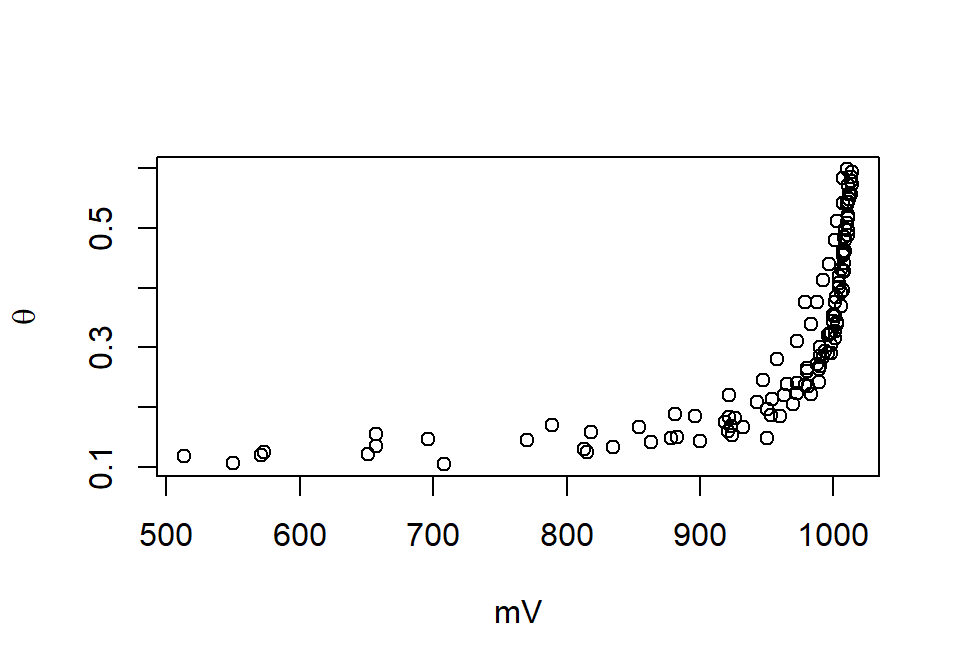

```r
plot(datos$V, datos$tita, xlab="mV",ylab=expression(theta))
```

### Rango de medida:

Utilizaremos las funciones máximo (max()) y mínimo (min()) para determinar los valores máximos y mínimos de voltaje de la serie.

```r
max(datos$V)
```

```
## [1] 1014
```

```r
min(datos$V)
```

```
## [1] 513
```

### Margen:

Calcularemos la diferencia entre el valor máximo y el mínimo de humedad

```r
titamax <- max(datos$tita)
titamin <- min(datos$tita)
titamax-titamin
```

```
## [1] 0.4946355
```

### Ajuste de la curva de calibrado:

La curva se puede ajustar de diversas formas. Después de realizar varias pruebas, se comprueba que la función que mejor se ajusta a la distribución de los datos es una polinomial de grado 3:

```
##
## Call:
## lm(formula = 1/tita ~ V + I(V^2) + I(V^3), data = datos)
##
## Residuals:
##     Min      1Q  Median      3Q     Max
## -1.5058 -0.2730  0.0015  0.3752  2.1511
##
## Coefficients:
##               Estimate Std. Error t value Pr(>|t|)
## (Intercept)  9.545e+01  1.439e+01   6.635 1.17e-09 ***
## V           -3.665e-01  5.629e-02  -6.510 2.15e-09 ***
## I(V^2)       5.074e-04  7.161e-05   7.086 1.26e-10 ***
## I(V^3)      -2.337e-07  2.974e-08  -7.858 2.50e-12 ***
## ---
## Signif. codes:  0 '***' 0.001 '**' 0.01 '*' 0.05 '.' 0.1 ' ' 1
##
## Residual standard error: 0.5847 on 113 degrees of freedom
## Multiple R-squared:  0.9205, Adjusted R-squared:  0.9184
## F-statistic: 436.1 on 3 and 113 DF,  p-value: < 2.2e-16
```

A partir de este resultado se pueden transformar los valores de voltaje en contenido volumétrico de agua en el suelo, aplicando la función polinomial de 3er grado que contenga los parámetros del modelo (estimate). Dichos parámetros se pueden extraer mediante código, también para representar la curva característica del sensor:

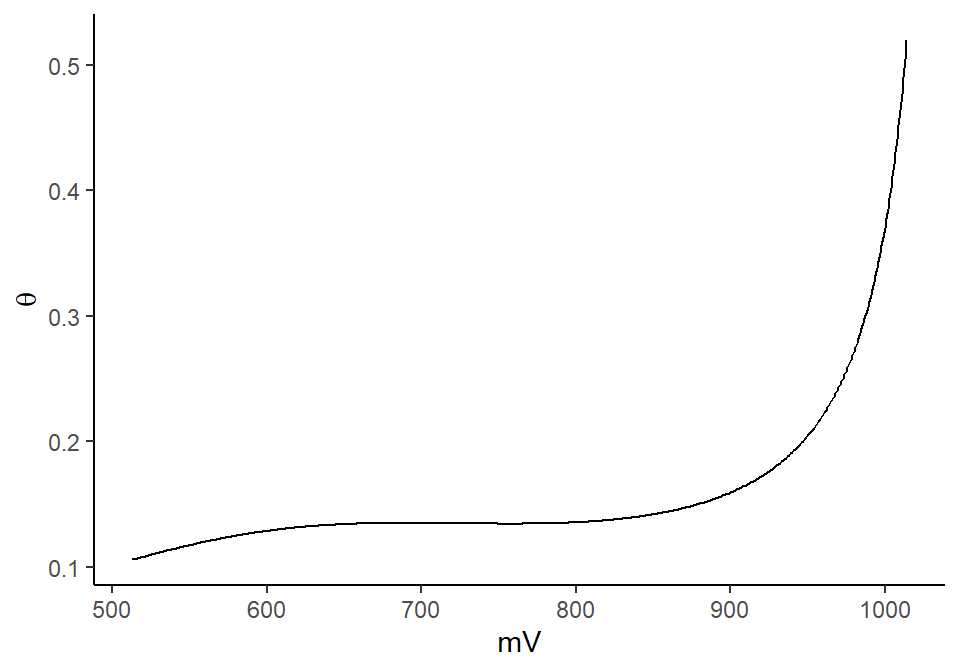